# CourseraML

Arup Mitra

2 November 2018

## Loading the Data

The initial setup activities related to loading the requisite libraries are carried out. Then the data files are downloaded from the URLs provided.

This consists of a training dataset and a 20 observations testing dataset.

```r
library(caret)
```

```r
library(rpart)
library(rpart.plot)
library(RColorBrewer)
library(RGtk2)
library(rattle)
library(randomForest)
UrlTrain <- "http://d396qusza40orc.cloudfront.net/predmachlearn/pml-training.csv"
UrlTest  <- "http://d396qusza40orc.cloudfront.net/predmachlearn/pml-testing.csv"

destfile<-"pml-training.csv"
# download the datasets
if (!file.exists(destfile)) {
        download.file(UrlTrain,"pml-training.csv")
        download.file(UrlTest,"pml-testing.csv")
}
dt_training <- read.csv("pml-training.csv")
dt_testing  <- read.csv("pml-testing.csv")
```

## Data Cleansing

- Remove all columns that contains NA (variance, mean, SD)
- Remove features that are not in the testing dataset.
- The testing dataset has no time-dependence, these values are useless and can be disregarded.
- The first 7 features are also removed since they are related to the time-series or are not numeric.

```
## [1] 19622    53
```

```
## [1] 20 53
```

## Data Partitioning

The data into a training data set (60% of the total cases) and a testing data set (40% of the total cases for allowing to estimate the out of sample error of the predictor).

```
## [1] 11776    53
```

```
## [1] 7846   53
```

## Build Decision Tree Model

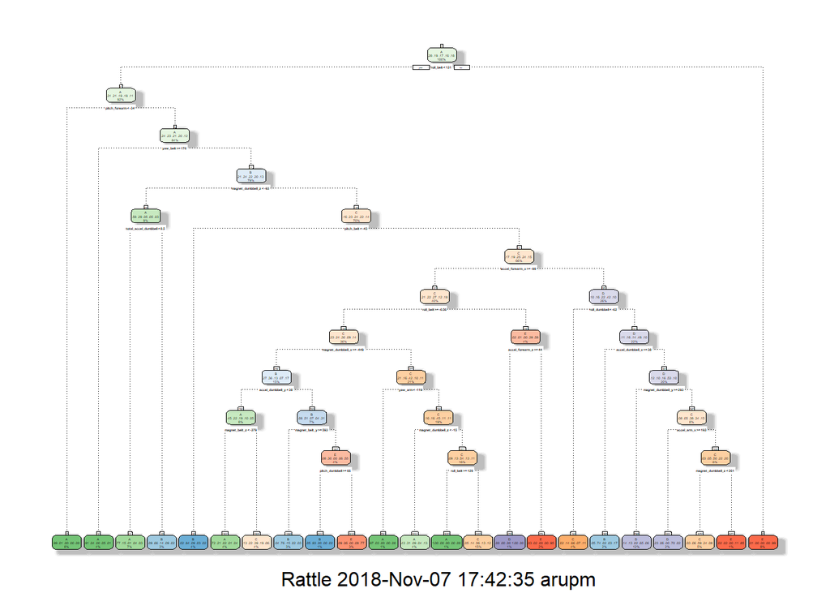

## Decision Tree Predictions

```
## Confusion Matrix and Statistics
##
##           Reference
## Prediction    A    B    C    D    E
##          A 1879  260   30   69   66
##          B   56  759   88   34   54
##          C  105  340 1226  354  234
##          D  155  132   23  807   57
##          E   37   27    1   22 1031
##
## Overall Statistics
##
##                Accuracy : 0.7267
##                  95% CI : (0.7167, 0.7366)
##     No Information Rate : 0.2845
##     P-Value [Acc > NIR] : < 2.2e-16
##
##                   Kappa : 0.6546
##  Mcnemar's Test P-Value : < 2.2e-16
##
## Statistics by Class:
##
##                      Class: A Class: B Class: C Class: D Class: E
## Sensitivity            0.8418  0.50000   0.8962   0.6275   0.7150
## Specificity            0.9243  0.96334   0.8405   0.9441   0.9864
## Pos Pred Value         0.8155  0.76589   0.5427   0.6874   0.9222
## Neg Pred Value         0.9363  0.88928   0.9746   0.9282   0.9389
## Prevalence             0.2845  0.19347   0.1744   0.1639   0.1838
## Detection Rate         0.2395  0.09674   0.1563   0.1029   0.1314
## Detection Prevalence   0.2937  0.12631   0.2879   0.1496   0.1425
## Balanced Accuracy      0.8831  0.73167   0.8684   0.7858   0.8507
```

## The Random Forest Model

Using random forest, the out of sample error should be small. The error will be estimated using the 40% testing sample, an error estimate of less than 3% is expected.

```
## Confusion Matrix and Statistics
##
##           Reference
## Prediction    A    B    C    D    E
##          A 2230    9    0    0    0
##          B    2 1505    7    0    0
##          C    0    4 1361   16    2
##          D    0    0    0 1268    4
##          E    0    0    0    2 1436
##
## Overall Statistics
##
##                Accuracy : 0.9941
##                  95% CI : (0.9922, 0.9957)
##     No Information Rate : 0.2845
##     P-Value [Acc > NIR] : < 2.2e-16
##
##                   Kappa : 0.9926
##  Mcnemar's Test P-Value : NA
##
## Statistics by Class:
##
##                      Class: A Class: B Class: C Class: D Class: E
## Sensitivity            0.9991   0.9914   0.9949   0.9860   0.9958
## Specificity            0.9984   0.9986   0.9966   0.9994   0.9997
## Pos Pred Value         0.9960   0.9941   0.9841   0.9969   0.9986
## Neg Pred Value         0.9996   0.9979   0.9989   0.9973   0.9991
## Prevalence             0.2845   0.1935   0.1744   0.1639   0.1838
## Detection Rate         0.2842   0.1918   0.1735   0.1616   0.1830
## Detection Prevalence   0.2854   0.1930   0.1763   0.1621   0.1833
## Balanced Accuracy      0.9988   0.9950   0.9957   0.9927   0.9978
```

## Prediction on Test Data

** Decision Tree Prediction

```
##  1  2  3  4  5  6  7  8  9 10 11 12 13 14 15 16 17 18 19 20
##  C  A  C  A  A  E  D  D  A  A  A  C  A  A  C  E  A  D  C  B
## Levels: A B C D E
```

** Random Forest Prediction

```
##  1  2  3  4  5  6  7  8  9 10 11 12 13 14 15 16 17 18 19 20
##  B  A  B  A  A  E  D  B  A  A  B  C  B  A  E  E  A  B  B  B
## Levels: A B C D E
```

*** Conclusion

Based on the above analysis, it can be stated that the Random Forest Model definitely provides a much more accurate prediction for this set of data.